# STAT 4580 hw1

## Brief Description

This is a data set that record waiting time between eruptions and the duration of the eruption for the Old Faithful geyser in Yellowstone National Parkt, Wyoming, USA.

There are two variables in this data set, **eruption**, the Eruption time (in mins) and **waiting**, the waiting time to next eruption (in mins). Below is the first six obeservations in this dataset.

```r
head(faithful)
```

```
##   eruptions waiting
## 1     3.600      79
## 2     1.800      54
## 3     3.333      74
## 4     2.283      62
## 5     4.533      85
## 6     2.883      55
```

We also have the summary of both variable.

```r
summary(faithful)
```

```
##    eruptions        waiting
##  Min.   :1.600   Min.   :43.0
##  1st Qu.:2.163   1st Qu.:58.0
##  Median :4.000   Median :76.0
##  Mean   :3.488   Mean   :70.9
##  3rd Qu.:4.454   3rd Qu.:82.0
##  Max.   :5.100   Max.   :96.0
```

From the summary above we can see that the eruption time is between 1.6 to 5.1 minutes with median of 4 minutes and mean of 3.488 minutes, and the waiting time is between 43 minutes to 96 minutes, with median of 76 and mean of 70.9 minutes.

## Plots

We conduct a plot of the faithful dataset, and we can observe that there is a linear association between eruptions and waiting. However, the observations are not spread out evenly, instead they are mainly seperated into two clusters.

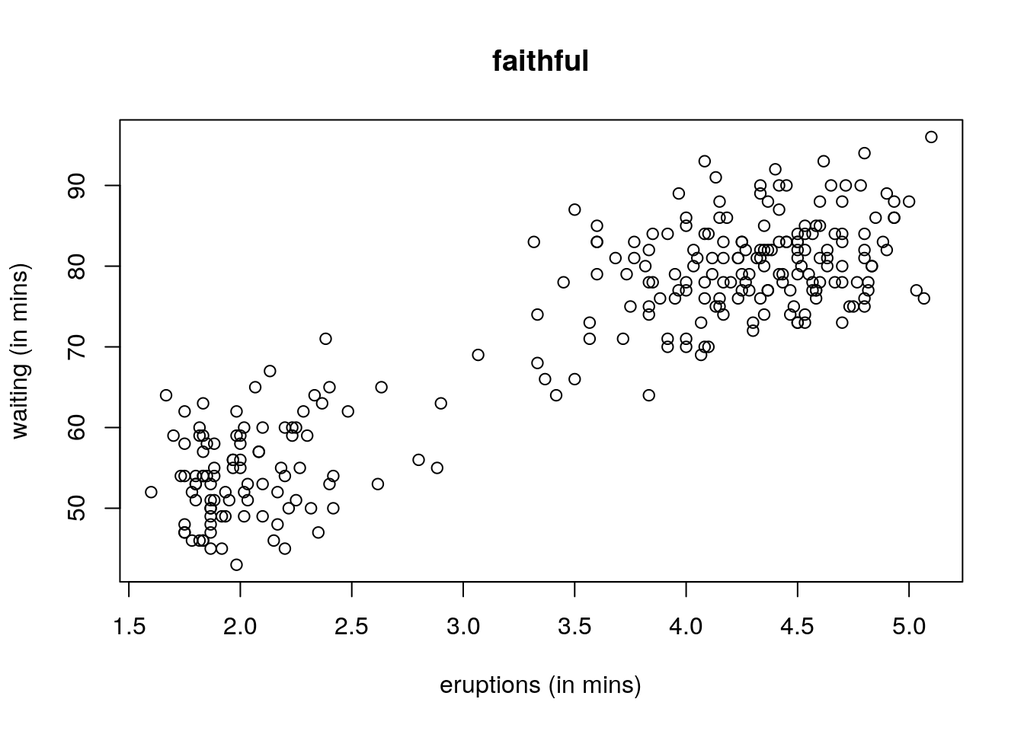

To take a closer look at this data set, we draw a histogram for each of the two variables.

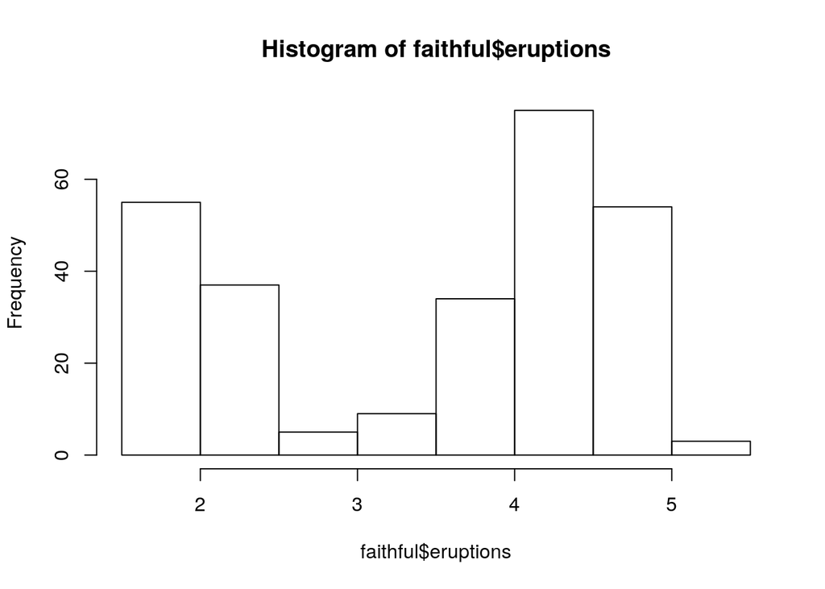

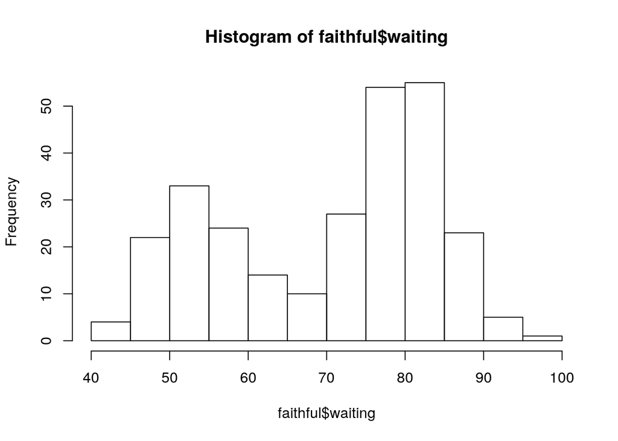

As we observed in the histograms, both of the two variables have bimodal distribution. Further investigation might be needed to make conclusion about the association.